# Figure 1D: Pseudotime analysis

Jason Cosgrove (jason.cosgrove@curie.fr)

Institut Curie, UMR168

# 1 Introduction

Model the differentiation of hematopoietic stem and progneitors using the PAGA algorithm, to understand how enzyme and transporter expression dynamics change over time

```r
#Set up the workspace
knitr::opts_chunk$set(echo = TRUE)
knitr::opts_knit$set(root.dir = '/Users/jasoncosgrove/Dropbox (Team_Perie)/Jason/Experiments/Dry_Lab/JCB4_metabolism_bioinformatics_pipeline')

#clear the workspace and set the working directory
rm(list = ls())

#load in the packages that we need to run this analysis
library(Seurat)
library(xgboost)
library(pROC)
library(dplyr)
```

```r
library(ggplot2)
library(pheatmap)
library(RColorBrewer)
library(Rmagic)
#source("module8_helpermethods.R")



#set the seed so we can reproduce the results
set.seed(12345)
```

# 2 Load the scRNAseq data

Load in the Dahlin dataset and perform cluster annotation using known lineage associated markers. This is a dataset of 44,802 cKit+ and cKit+ Sca1+ HSPCs sequencing using the 10X genomics platform

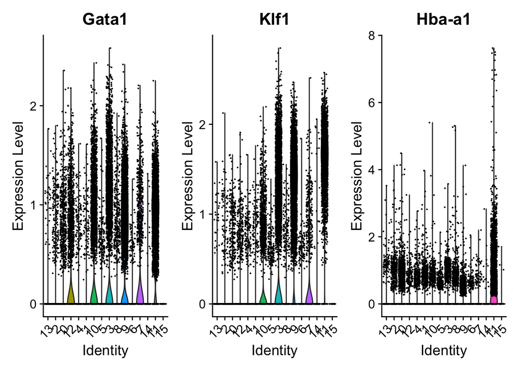

```r
#load in teh haemopedia dataset in the form of a seurat object
load("datasets/Dahlin/Dahlin_SeuratObject.Rda")

E.markers <- c("Gata1","Klf1","Hba-a1")
Neu.markers <- c("Elane", "Ctsg", "Mpo")
Mono.markers <- c("Irf8","Csf1r")
Meg.markers <- c("Itga2b", "Vwf")
Baso.markers <- c("Mcpt8","Prss34")
B.markers <- c("Cd19","Vpreb2","Cd79a")
Mast.markers <- c("Cma1","Gzmb")
mast.baso.markers <- c("Ms4a2", "Fcer1a")



#use a violin plot visualisation to look for which clusters are lineage primed
Idents(dahlin) <- dahlin@meta.data$clusters
VlnPlot(dahlin, features = E.markers,pt.size = 0.1)#cluster 3 and 9 also
```

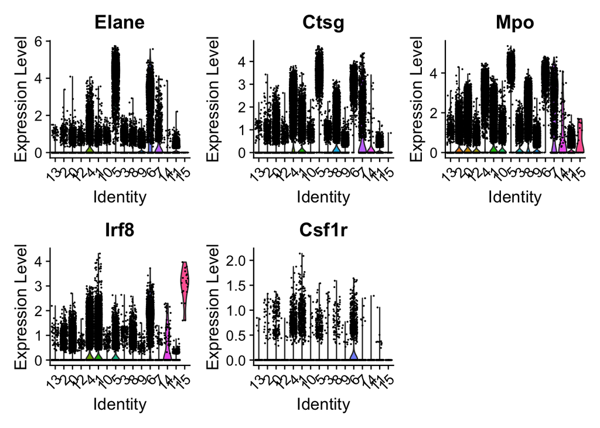

```r
VlnPlot(dahlin, features = c(Neu.markers,Mono.markers),pt.size = 0.1)#cluster 3 and 9 also
```

# 3 Data imputation

scRNAseq data is very sparse and this limits our ability to visualise transporter and enzyme dynamics along lineage differentiation trajectories. To deal with this issue we use MAGIC (Markov affinity-based graph imputation of cells) - a method for addressing technical noise in single-cell data, including under-sampling of mRNA molecules, often termed “dropout” which can severely obscure important gene-gene relationships. MAGIC shares information across similar cells, via data diffusion, to denoise the cell count matrix and fill in missing transcripts. Read more: van Dijk et al. (2018) doi:10.1016/j.cell.2018.05.061.

```r
dahlin<- magic(dahlin,npca = 10)
```

```
## [1] "Added MAGIC output to MAGIC_RNA. To use it, pass assay='MAGIC_RNA' to downstream methods or set seurat_object@active.assay <- 'MAGIC_RNA'."
```

```r
DefaultAssay(dahlin) <- "MAGIC_RNA"
dahlin <- ScaleData(dahlin, verbose = FALSE)
```

# 4 Define the lineage differentiation trajectories

Use our PAGA based annotation - calculated already in python using the scanpy package - to define lineage differentiation trajectories.

```r
#lets merge the MPP clusters, we dont get much info from this increased resolution
dahlin@meta.data$clusters[dahlin@meta.data$clusters == 0] <- 2
Idents(dahlin) <- dahlin@meta.data$clusters

#set the trajectories that you are interested in based on our clustering-based cell-state transition model from PAGA
erythrocytes <- c(13,2, 8,10, 3,9, 11)
monocytes <- c(13,2,8, 4,6)
basophils<- c(13,2,8, 4,7)
neutrophils<- c(13,2,8, 4,5)
myeloid <- c(13,2,8, 4,6,5)
lymphoid<- c(13,2, 1,14)
```

# 5 Model the myeloid differentiation trajectory

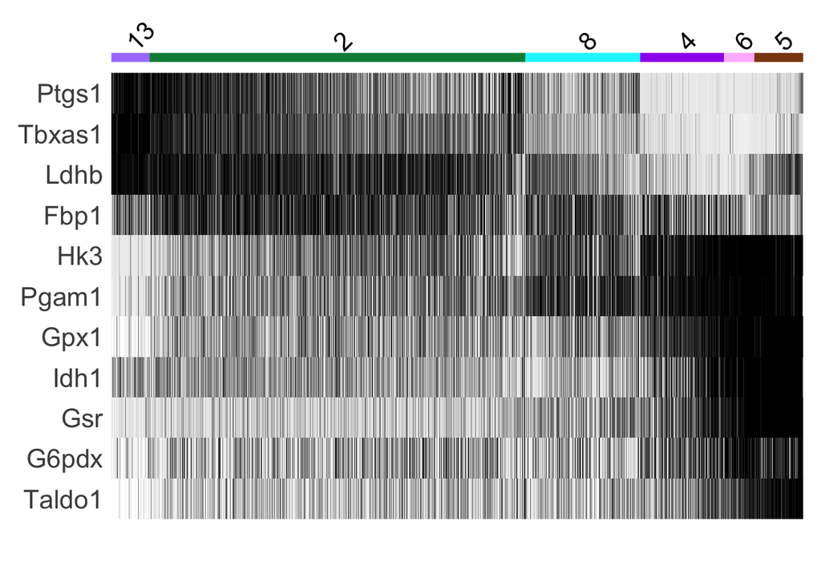

```r
#subset the data to include only the myeloid relevant clusters
dahlin.subset <- subset(dahlin,idents = myeloid)
trajectory <- myeloid

#organise the cells by cluster and then by psuedotime
df <- data.frame(dahlin.subset@meta.data[,colnames(dahlin.subset@meta.data) == "clusters" | colnames(dahlin.subset@meta.data) == "dpt.pseudotime"])
df$clusters <- factor(df$clusters, levels = trajectory)
df <- df[order(df$clusters,df$dpt.pseudotime),]
df$cell <- rownames(df)

dahlin.subset@active.ident <- factor(dahlin.subset@active.ident,levels=trajectory)
custom_order <- df$cell
genes.to.plot <- c("Ptgs1","Tbxas1","Ldhb","Fbp1","Hk3","Pgam1",
                  "Gpx1","Idh1","Gsr","G6pdx","Taldo1")


#choose the colors to keep the same color scheme as in figure 1C.
myeloid.colors <- c("mediumpurple1","springgreen4","turquoise1","purple","plum1","saddlebrown")

#tiff("/Users/jasoncosgrove/Desktop/heatmapM.tiff", width = 5,
#     height = 4, units = 'in', res = 300)
p <- DoHeatmap(dahlin.subset, features = c(genes.to.plot
                                           ),cells = df$cell,
               disp.min = -1.5, disp.max = 1.5,draw.lines = F,group.colors = myeloid.colors) +NoLegend() + scale_fill_gradientn(colors = c("white","grey90","grey30","black")) + theme(text = element_text(size = 20))
p
```

```r
#dev.off()
```

# 6 Model the erythroid differentiation trajectory

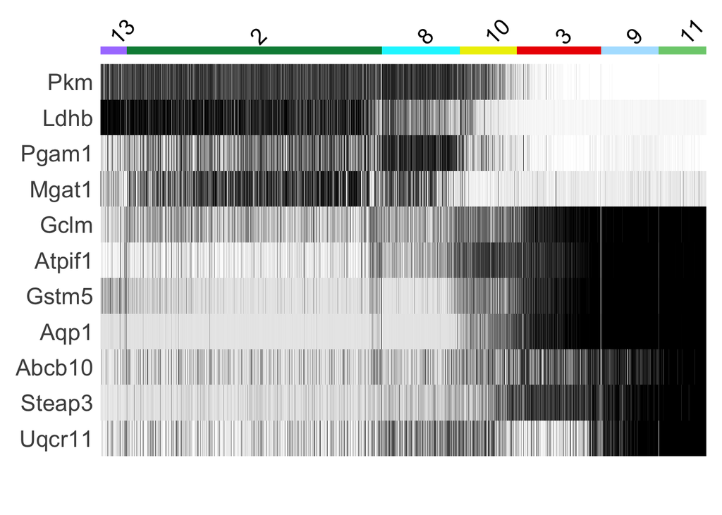

```r
dahlin.subset <- subset(dahlin,idents = erythrocytes)
trajectory <- erythrocytes

df <- data.frame(dahlin.subset@meta.data[,colnames(dahlin.subset@meta.data) == "clusters" | colnames(dahlin.subset@meta.data) == "dpt.pseudotime"])
df$clusters <- factor(df$clusters, levels = trajectory)
df <- df[order(df$clusters,df$dpt.pseudotime),]
df$cell <- rownames(df)


dahlin.subset@active.ident <- factor(dahlin.subset@active.ident,levels=trajectory)
custom_order <- df$cell


ery.colors <- c("mediumpurple1","springgreen4","turquoise1","yellow2","red2","lightskyblue1","palegreen3")

#tiff("/Users/jasoncosgrove/Desktop/heatmapE.tiff", width = 5,
#     height = 4, units = 'in', res = 300)
p <- DoHeatmap(dahlin.subset, features = c("Pkm","Ldhb","Pgam1","Mgat1","Gclm","Atpif1","Gstm5","Aqp1","Abcb10","Steap3","Uqcr11"
                                           ),cells = df$cell,
               disp.min = -1.5, disp.max = 1.5,draw.lines = F,group.colors = ery.colors) +NoLegend() + scale_fill_gradientn(colors = c("white","grey90","grey30","black")) + theme(text = element_text(size = 20))
p
```

```r
#dev.off()
```